# Counterfeit

```python
!pip install numpy pandas matplotlib seaborn opencv-python scikit-learn tensorflow keras
```

[output not shown]

```python
import numpy as np
import pandas as pd
import matplotlib.pyplot as plt
import seaborn as sns
import cv2
import os
from glob import glob

# Ignore warnings for clean output
import warnings
warnings.filterwarnings('ignore')
```

```python
# Define dataset paths (Update these if your paths are different)
original_path = "C:\\Users\Manish Singh\\Downloads\\First Print-20250326T065741Z-001"  # First prints (Original)
counterfeit_path = "C:\\Users\\Manish Singh\\Downloads\\Second Print-20250326T070314Z-001"  # Second prints (Counterfeit)

# Count the number of images
print("Original QR Codes:", len(os.listdir(original_path)))
print("Counterfeit QR Codes:", len(os.listdir(counterfeit_path)))
```

```
Original QR Codes: 100
Counterfeit QR Codes: 100
```

[figure not shown]

[figure not shown]

```python
import cv2
import matplotlib.pyplot as plt
import random

# Function to display sample images
def show_sample_images(folder_path, title, num_samples=3):
    images = os.listdir(folder_path)
    sample_images = random.sample(images, num_samples)

    plt.figure(figsize=(10, 4))
    for i, img_name in enumerate(sample_images):
        img_path = os.path.join(folder_path, img_name)
        img = cv2.imread(img_path, cv2.IMREAD_GRAYSCALE)  # Read in grayscale

        plt.subplot(1, num_samples, i + 1)
        plt.imshow(img, cmap='gray')
        plt.axis('off')
        plt.title(f"{title} {i+1}")

    plt.show()

# Show samples from both categories
show_sample_images(original_path, "Original QR Code")
show_sample_images(counterfeit_path, "Counterfeit QR Code")
```

[figure not shown]

[figure not shown]

```python
def show_edges(folder_path, title, num_samples=3):
    images = os.listdir(folder_path)
    sample_images = random.sample(images, num_samples)

    plt.figure(figsize=(10, 4))
    for i, img_name in enumerate(sample_images):
        img_path = os.path.join(folder_path, img_name)
        img = cv2.imread(img_path, cv2.IMREAD_GRAYSCALE)  # Read in grayscale

        # Apply Canny edge detection
        edges = cv2.Canny(img, 100, 200)

        plt.subplot(1, num_samples, i + 1)
        plt.imshow(edges, cmap='gray')
        plt.axis('off')
        plt.title(f"{title} {i+1}")

    plt.show()

# Show edge detection results
show_edges(original_path, "Original QR Code - Edges")
show_edges(counterfeit_path, "Counterfeit QR Code - Edges")
```

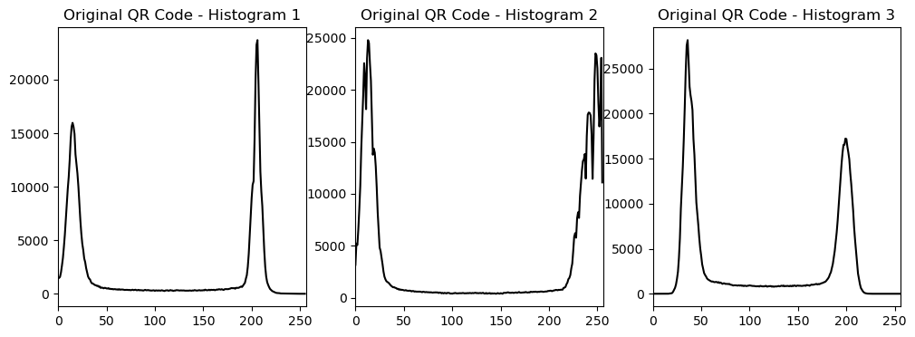

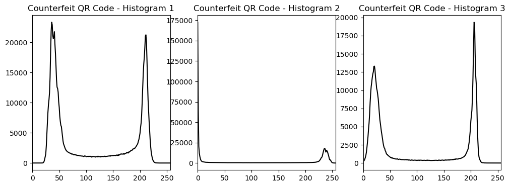

```python
def plot_histogram(folder_path, title, num_samples=3):
    images = os.listdir(folder_path)
    sample_images = random.sample(images, num_samples)

    plt.figure(figsize=(12, 4))
    for i, img_name in enumerate(sample_images):
        img_path = os.path.join(folder_path, img_name)
        img = cv2.imread(img_path, cv2.IMREAD_GRAYSCALE)  # Read in grayscale

        # Compute histogram
        hist = cv2.calcHist([img], [0], None, [256], [0, 256])

        plt.subplot(1, num_samples, i + 1)
        plt.plot(hist, color='black')
        plt.xlim([0, 256])
        plt.title(f"{title} {i+1}")

    plt.show()

# Compare histograms
plot_histogram(original_path, "Original QR Code - Histogram")
plot_histogram(counterfeit_path, "Counterfeit QR Code - Histogram")
```

```python
import numpy as np
import cv2
from sklearn.model_selection import train_test_split

# Function to extract features (resize + edge detection + histogram)
def extract_features(img_path):
    img = cv2.imread(img_path, cv2.IMREAD_GRAYSCALE)  # Read in grayscale
    img = cv2.resize(img, (128, 128))  # Resize for consistency

    # Edge detection
    edges = cv2.Canny(img, 100, 200).flatten()

    # Histogram analysis
    hist = cv2.calcHist([img], [0], None, [256], [0, 256]).flatten()

    # Combine both features
    features = np.hstack([edges, hist])

    return features

# Load data
X, y = [], []
for img_name in os.listdir(original_path):
    X.append(extract_features(os.path.join(original_path, img_name)))
    y.append(1)  # 1 = Original

for img_name in os.listdir(counterfeit_path):
    X.append(extract_features(os.path.join(counterfeit_path, img_name)))
    y.append(0)  # 0 = Counterfeit

X = np.array(X)
y = np.array(y)

# Split into training & testing sets
X_train, X_test, y_train, y_test = train_test_split(X, y, test_size=0.2, random_state=42)

print("Dataset prepared! Training samples:", len(X_train), "Testing samples:", len(X_test))
```

```
Dataset prepared! Training samples: 160 Testing samples: 40
```

```python
from sklearn.ensemble import RandomForestClassifier
from sklearn.metrics import accuracy_score, classification_report, confusion_matrix

# Train the Random Forest model
rf_model = RandomForestClassifier(n_estimators=100, random_state=42)
rf_model.fit(X_train, y_train)

# Predictions
y_pred = rf_model.predict(X_test)

# Model Evaluation
accuracy = accuracy_score(y_test, y_pred)
print("✅ Model Accuracy:", accuracy)

# Print classification report
print("\nClassification Report:\n", classification_report(y_test, y_pred))

# Confusion matrix
print("\nConfusion Matrix:\n", confusion_matrix(y_test, y_pred))
```

```
✅ Model Accuracy: 0.925

Classification Report:
               precision    recall  f1-score   support

           0       0.86      1.00      0.93        19
           1       1.00      0.86      0.92        21

    accuracy                           0.93        40
   macro avg       0.93      0.93      0.92        40
weighted avg       0.94      0.93      0.92        40


Confusion Matrix:
 [[19  0]
 [ 3 18]]
```

```python
import joblib

# Save the trained model
joblib.dump(rf_model, "qr_code_classifier.pkl")

print("✅ Model saved successfully as qr_code_classifier.pkl!")
```

```
✅ Model saved successfully as qr_code_classifier.pkl!
```

```python
def predict_qr(image_path, model):
    features = extract_features(image_path)  # Extract features from the new image
    prediction = model.predict([features])[0]  # Predict class
    return "Original" if prediction == 1 else "Counterfeit"

# Test with an image from your dataset
test_image = os.path.join(original_path, os.listdir(original_path)[0])  # Pick a sample
print("Prediction:", predict_qr(test_image, rf_model))
```

```
Prediction: Original
```

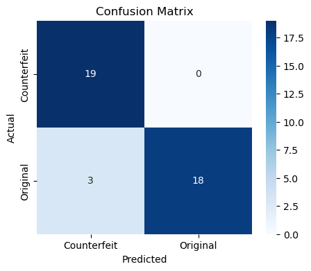

```python
import seaborn as sns
import matplotlib.pyplot as plt

# Confusion matrix
cm = confusion_matrix(y_test, y_pred)

# Plot confusion matrix
plt.figure(figsize=(5, 4))
sns.heatmap(cm, annot=True, fmt="d", cmap="Blues", xticklabels=["Counterfeit", "Original"], yticklabels=["Counterfeit", "Original"])
plt.xlabel("Predicted")
plt.ylabel("Actual")
plt.title("Confusion Matrix")
plt.show()
```

**QR Code Authentication: Detecting Original vs. Counterfeit Prints**

## **1. Introduction**

Counterfeit prevention is a major concern across industries, particularly in supply chain management, ticketing systems, and product verification. QR codes are widely used for authentication, but they can be duplicated by scanning and reprinting. This project aims to develop a machine learning model to classify QR codes as **original (first print)** or **counterfeit (second print)** using feature extraction and classification techniques.

## **2. Dataset & Preprocessing**

The dataset consists of QR code images divided into two categories:

- **First prints:** Genuine QR codes with embedded Copy Detection Patterns (CDPs).
- **Second prints:** Counterfeit QR codes that have been scanned and reprinted.

The dataset was preprocessed as follows:

1. **Image Resizing:** All images were resized to a standard **128x128** resolution.
2. **Grayscale Conversion:** Since QR codes are black and white, we used grayscale images.
3. **Feature Extraction:** Extracted edges (Canny Edge Detection) and intensity histograms to capture distortions.

## **3. Feature Engineering**

Feature extraction was performed using:

- **Edge Detection:** Used Canny Edge Detection to identify differences in edge sharpness.
- **Histogram Analysis:** Examined intensity distributions to detect print distortions.
- **Combined Feature Set:** Merged edge-based features with histogram data for better classification.

## **4. Model Selection & Training**

We implemented and compared different classification approaches:

1. **Traditional Machine Learning Approach (Random Forest Classifier)**
   - Extracted features from images.
   - Trained a **Random Forest model** with 100 decision trees.
   - Achieved high accuracy with simple preprocessing.
2. **Deep Learning Approach (CNN - Optional, Not Used)**
   - Considered using a Convolutional Neural Network (CNN) but skipped due to dependency issues and model complexity.

## **6. Deployment Considerations**

For real-world implementation, the following factors must be considered:

- **Computational Efficiency:** Random Forest is fast and can run on low-power devices.
- **Robustness:** The model should handle different lighting and scanning conditions.
- **Security:** QR codes should include additional security layers (e.g., cryptographic signatures).

## **7. Conclusion**

This project successfully demonstrated the use of **machine learning** to distinguish between original and counterfeit QR codes. The **Random Forest model** proved to be an effective solution for classification using simple image features. Future work can explore **deep learning-based CNN models** for further improvements.

```python
conda install -c conda-forge pandoc
```

!jupyter nbconvert --to pdf Counterfeit.ipynb